# Краткое введение в мир матричной алгебры

## Вы сможете

- Объяснить что такое матрицы и какие бывают их основные разновидности
- Выполнить базовые операции с матрицами с использованием функций R
- Применить в среде R методы матричной алгебры для решения простейших задач

## Зачем нужны матрицы?

## Матричные объекты

- Есть много типов объектов, для которых такое выражение оказывается наиболее етсественным (изображения, описания многомерных объектов и т.д.)
- В матрицах, как и в обычных числах, скрыта информация, которую можно извлекать и преобразовывать по определнным правилам

## Структура матриц

\[\begin{pmatrix} a_{11} & a_{12} & \cdots & a_{1c} \\ a_{21} & a_{22} & \cdots & a_{2c} \\ \vdots & \vdots & \ddots & \vdots \\ a_{r1} & a_{r2} & \cdots & a_{rc} \end{pmatrix} \]

Размер (порядок) матрицы \(r \times c\)

## Разновидности матриц

Вектор-строка (row matrix) \[ \textbf {A} = \begin{pmatrix} 1 & 2 & 3 \end{pmatrix} \]

Вектор-столбец (column matrix)

\[ \textbf {B} = \begin{pmatrix} 1 \\ 4 \\ 7 \\ 10 \end{pmatrix} \]

## Разновидности матриц

Прямоугольные матрицы (rectangular matrices)

\[ \textbf {C} = \begin{pmatrix} 1 & 2 & 3 \\ 4 & 5 & 6 \\ 7 & 8 & 9 \\ 10 & 11 & 12 \end{pmatrix} \]

\[ \textbf {D} = \begin{pmatrix} 1 & 2 & 3 \\ 4 & 5 & 6 \end{pmatrix} \]

В таком виде обычно представляются исходные данные

## Квадратные матрицы (square matrices)

Это наиболее "операбельные" матрицы

\[ \textbf {E} = \begin{pmatrix} 1 & 2 & 3 \\ 4 & 5 & 6 \\ 7 & 8 & 9 \end{pmatrix} \]

Диагональные матрицы (diagonal matrix)

\[ \textbf {F} = \begin{pmatrix} 1 & 0 & 0 & 0 \\ 0 & 5 & 0 & 0 \\ 0 & 0 & 9 & 0 \\ 0 & 0 & 0 & 1 \end{pmatrix} \]

## Квадратные матрицы (square matrices)

Треугольные матрицы (triangular matrices) \[ \textbf {H} = \begin{pmatrix} 1 & 2 & 3 & 4 \\ 0 & 5 & 6 & 7 \\ 0 & 0 & 9 & 10 \\ 0 & 0 & 0 & 1 \end{pmatrix} \]

или

\[ \textbf {H} = \begin{pmatrix} 1 & 0 & 0 & 0 \\ 3 & 5 & 0 & 0 \\ 4 & 7 & 9 & 0 \\ 5 & 8 & 10 & 11 \end{pmatrix} \]

## Квадратные матрицы (square matrices)

Единичная матрица (identity matrix) \[ \textbf {I} = \begin{pmatrix} 1 & 0 & 0 & 0 \\ 0 & 1 & 0 & 0 \\ 0 & 0 & 1 & 0 \\ 0 & 0 & 0 & 1 \end{pmatrix} \]

Единичная матрица (обозначение \(\textbf{I}\)) занимают особое место в матричной алгебре.  
Она выполняет ту же роль, которую выполняет единица в обычной алгебре.

## Матрицы ассоциации

Изначально результаты исследования имеют вид исходной матрицы (обычно прямоугольной)

\[ \textbf{Y} = [n_{objects} \times p_{descriptors}]\]

Информация из этой матрицы конденсируется в двух других матрицах

Q анализ

\[ \textbf{A}_{nn} = [n_{objects} \times n_{objects}]\]

R анализ \[ \textbf{A}_{pp} = [p_{descriptors} \times p_{descriptors}]\]

## Матрицы ассоциации

Это симметричные квадратные матрицы

\[ \textbf{A}_{pp} = \begin{pmatrix} a_{11} & a_{12} & \cdots & a_{1p} \\ a_{21} & a_{22} & \cdots & a_{2p} \\ \vdots & \vdots & \ddots & \vdots \\ a_{p1} & a_{p2} & \cdots & a_{pp} \end{pmatrix} \]

В этой матрице \(a_{ij} = a_{ji}\)

Большинство многомерных методов имеет дело именно с такими матрицами

## Особенность квадратных матриц

Для квадратных матриц могут быть найдены (но не обязательно существуют) некоторые важные для матричной алгебры показатели: *определитель*, *инверсия*, *собственные значения* и *собственные вектора*

## Задание

Создайте с помощью R следующие матрицы

```
##      [,1] [,2] [,3]
## [1,]    1    5    9
## [2,]    2    6   10
## [3,]    3    7   11
## [4,]    4    8   12
```

```
##      [,1] [,2] [,3] [,4] [,5]
## [1,]    1    0    0    0    0
## [2,]    0    1    0    0    0
## [3,]    0    0    1    0    0
## [4,]    0    0    0    1    0
## [5,]    0    0    0    0    1
```

## Операции с матрицами

## Транспонирование матриц

```r
A <- matrix(1:12, ncol = 3)
A
```

```
##      [,1] [,2] [,3]
## [1,]    1    5    9
## [2,]    2    6   10
## [3,]    3    7   11
## [4,]    4    8   12
```

Транспонированная матрица \(\textbf{A}\)

```r
B <- t(A)
B
```

```
##      [,1] [,2] [,3] [,4]
## [1,]    1    2    3    4
## [2,]    5    6    7    8
## [3,]    9   10   11   12
```

## Сложение матриц

```r
A + 4
```

```
##      [,1] [,2] [,3]
## [1,]    5    9   13
## [2,]    6   10   14
## [3,]    7   11   15
## [4,]    8   12   16
```

```r
A + A
```

```
##      [,1] [,2] [,3]
## [1,]    2   10   18
## [2,]    4   12   20
## [3,]    6   14   22
## [4,]    8   16   24
```

Но! Нельзя складывать матрицы разных размеров

```r
A + B
```

## Биологическое приложение

Предположим, что мы подсчитывали двумя разными методами крупных и мелких животных трех видов в одних и тех же пробах

```
##         Sp1 Sp2 Sp3
## Sample1   8  10   9
## Sample2   9   7  12
## Sample3  10   9  12
## Sample4  10  10  11
## Sample5  11  11   8
```

```
##         Sp1 Sp2 Sp3
## Sample1  55  49  58
## Sample2  49  47  49
## Sample3  44  49  54
## Sample4  43  49  56
## Sample5  57  55  57
```

Общее обилие

```r
Large + Small
```

```
##         Sp1 Sp2 Sp3
## Sample1  63  59  67
## Sample2  58  54  61
## Sample3  54  58  66
## Sample4  53  59  67
## Sample5  68  66  65
```

## Простое умножение

Умножение на число

```r
A * 4
```

```
##      [,1] [,2] [,3]
## [1,]    4   20   36
## [2,]    8   24   40
## [3,]   12   28   44
## [4,]   16   32   48
```

Простое умножение матрицы на вектор возможно только если число элементов в векторе равно числу строк в матрице

```r
A * c(10, 11, 12, 13)
```

```
##      [,1] [,2] [,3]
## [1,]   10   50   90
## [2,]   22   66  110
## [3,]   36   84  132
## [4,]   52  104  156
```

Все элементы первой строки матрицы умножаются на первый элемент вектора, все элементы второй строки на второй элемент вектора и т.д.

## Биологическое применение

Допустим, учет организмов в части описаний проходил не на всей выборке, а лишь в ее части.

```r
Rpocessed_portion <- c(1, 1, 1/2, 1/3, 1/4)
Processed_Factor <- 1/Rpocessed_portion
```

```r
Small * Processed_Factor
```

```
##         Sp1 Sp2 Sp3
## Sample1  55  49  58
## Sample2  49  47  49
## Sample3  88  98 108
## Sample4 129 147 168
## Sample5 228 220 228
```

## Длина вектора

Длина вектора, или норма вектора

\[ ||\textbf{b}|| = \sqrt{b_1^2 + b_2^2 + \dots + b_n^2} \]

Нормализованный вектор \[ \textbf{c} = \textbf{b} \cdot 1/||\textbf{b}|| \]

## Задание

Найдите нормализованный вектор для следующего вектора

```r
Vec <- 1:5
Vec
```

```
## [1] 1 2 3 4 5
```

## Решение

```r
Vec/sqrt(sum(Vec^2))
```

```
## [1] 0.135 0.270 0.405 0.539 0.674
```

```r
Vec/norm(t(Vec), type = "F")
```

```
## [1] 0.135 0.270 0.405 0.539 0.674
```

## Скалярное произведение векторов

Допустимо только для векторов одинаковой размерности

\[ \textbf{a} \bullet \textbf{b} = \begin{pmatrix} a_1 \\ a_3 \\ a_4 \\ a_5 \\ a_6 \\ a_7 \end{pmatrix} \times \begin{pmatrix} b_1 & b_3 & b_4 & b_5 & b_6 & b_7 \end{pmatrix} = x \]

Результат этой операции - число (скаляр)

## Биологическое применение

Сколько особей родится в популяции, если мы знаем репродуктивные характеристики всех возрастных групп? \[ \begin{pmatrix} N_1 \\ N_3 \\ N_4 \\ N_5 \\ N_6 \\ N_7 \end{pmatrix} \times \begin{pmatrix} F_1 & F_2 & F_3 & F_4 & F_5 & F_6 & F_7 \end{pmatrix} \]

```r
N <- c(20, 40, 32, 45, 80, 50, 10)
Fert <- c( 0,  0,   1,   2,   2,   0,   0)

t(N) %*% (Fert)
```

```
##      [,1]
## [1,]  282
```

## Умножение матриц

Умножать можно только в том случае, если число строк одной матрицы равно числу столбцов другой матрицы

```r
A %*% B
```

```
##      [,1] [,2] [,3] [,4]
## [1,]  107  122  137  152
## [2,]  122  140  158  176
## [3,]  137  158  179  200
## [4,]  152  176  200  224
```

```r
A %*% t(A)
```

```
##      [,1] [,2] [,3] [,4]
## [1,]  107  122  137  152
## [2,]  122  140  158  176
## [3,]  137  158  179  200
## [4,]  152  176  200  224
```

НО! Нельзя произвести такое умножение

```r
A %*% A
```

## Биологическое применение

Простейший пример использования умножения матрц - построение модели динамики демографической структуры популяции Для вычислений необходим начальный *демографический вектор* и *матрица Лесли*

\[ \begin{pmatrix} F_1 & F_2 & F_3 & F_4 & F_5 & F_6 & F_7 \\ P_{1-2}& 0 & 0 & 0 & 0 & 0 & 0 \\ 0 & P_{2-3} & 0 & 0 & 0 & 0 & 0 \\ 0 & 0 & P_{3-4} & 0 & 0 & 0 & 0 \\ 0 & 0 & 0 & P_{4-5} & 0 & 0 & 0 \\ 0 & 0 & 0 & 0 & P_{5-6} & 0 & 0 \\ 0 & 0 & 0 & 0 & 0 & P_{6-7} & 0 \end{pmatrix} \times \begin{pmatrix} N1_t \\ N3_t \\ N4_t \\ N5_t \\ N6_t \\ N7_t \end{pmatrix} = \begin{pmatrix} N1_{t+1} \\ N3_{t+1} \\ N4_{t+1} \\ N5_{t+1} \\ N6_{t+1} \\ N7_{t+1} \end{pmatrix} \]

## Простейшая демографическая модель

Демографический вектор в момент времени \(t\)

```
##     Age T1
## 1     0 20
## 2  1-10 40
## 3 11-20 32
## 4 21-35 45
## 5 36-45 80
## 6 46-55 50
## 7 56-65 10
```

Матрица Лесли

```
##      [,1] [,2] [,3] [,4] [,5] [,6] [,7]
## [1,]  0.0  0.0  1.0  2.0  2.0  0.0    0
## [2,]  0.6  0.0  0.0  0.0  0.0  0.0    0
## [3,]  0.0  0.7  0.0  0.0  0.0  0.0    0
## [4,]  0.0  0.0  0.8  0.0  0.0  0.0    0
## [5,]  0.0  0.0  0.0  0.7  0.0  0.0    0
## [6,]  0.0  0.0  0.0  0.0  0.6  0.0    0
## [7,]  0.0  0.0  0.0  0.0  0.0  0.2    0
```

## Демографическая струкутра в момент времени \(t+1\)

```r
Pop$T2 <- as.vector( Lesl %*% (Pop$T1 ))
Pop$T3 <- as.vector( Lesl %*% (Pop$T2 ))
Pop$T4 <- as.vector( Lesl %*% (Pop$T3 ))
Pop$T5 <- as.vector( Lesl %*% (Pop$T4 ))
Pop$T6 <- as.vector( Lesl %*% (Pop$T5 ))
Pop$T7 <- as.vector( Lesl %*% (Pop$T6 ))
Pop$T8 <- as.vector( Lesl %*% (Pop$T7 ))
Pop$T9 <- as.vector( Lesl %*% (Pop$T8 ))
Pop$T10 <- as.vector( Lesl %*% (Pop$T9 ))
```

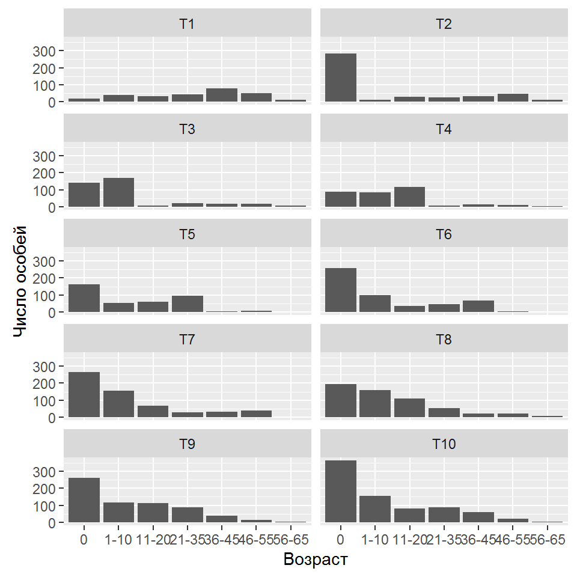

## Некоторые свойства произведения матриц

1. Если существует произведение матриц \(\textbf{BC}\), то не обязательно существует \(\textbf{CB}\)

```r
B <- matrix(1:24, ncol = 4)
C <- matrix(1:12, ncol = 3)

B %*% C
```

```
##      [,1] [,2] [,3]
## [1,]  130  290  450
## [2,]  140  316  492
## [3,]  150  342  534
## [4,]  160  368  576
## [5,]  170  394  618
## [6,]  180  420  660
```

HO!

```r
C %*% B
```

Такое произведение невозможно

## Некоторые свойства произведения матриц

1. Всегда существует такое произведение матриц \(\textbf{CС'}\) и \(\textbf{C'С}\)

```r
C %*% t(C)
```

```
##      [,1] [,2] [,3] [,4]
## [1,]  107  122  137  152
## [2,]  122  140  158  176
## [3,]  137  158  179  200
## [4,]  152  176  200  224
```

```r
t(C) %*% C
```

```
##      [,1] [,2] [,3]
## [1,]   30   70  110
## [2,]   70  174  278
## [3,]  110  278  446
```

## Некоторые свойства произведения матриц

1. Произведение матриц \(\textbf{BC}\) как правило не равно \(\textbf{CB}\)

```r
B <- matrix(1:9, ncol = 3)
C <- matrix(11:19, ncol = 3)

B %*%  C
```

```
##      [,1] [,2] [,3]
## [1,]  150  186  222
## [2,]  186  231  276
## [3,]  222  276  330
```

```r
C %*% B
```

```
##      [,1] [,2] [,3]
## [1,]   90  216  342
## [2,]   96  231  366
## [3,]  102  246  390
```

## Некоторые свойства произведения матриц

1. \([\textbf{BC}]' = \textbf{C}'\textbf{B}'\)

```r
t(B %*% C)
```

```
##      [,1] [,2] [,3]
## [1,]  150  186  222
## [2,]  186  231  276
## [3,]  222  276  330
```

```r
t(C) %*% t(B)
```

```
##      [,1] [,2] [,3]
## [1,]  150  186  222
## [2,]  186  231  276
## [3,]  222  276  330
```

## Некоторые свойства произведения матриц

1. Произведение \(\textbf{BB'}\) и \(\textbf{B'B}\) всегда дает симметричную матрицу

```r
B %*% t(B)
```

```
##      [,1] [,2] [,3]
## [1,]   66   78   90
## [2,]   78   93  108
## [3,]   90  108  126
```

```r
t(B) %*% B
```

```
##      [,1] [,2] [,3]
## [1,]   14   32   50
## [2,]   32   77  122
## [3,]   50  122  194
```